# dba_homework

xiaolin

2019/5/14

# 研究背景

FoodMart（以下简称“FoodMart”或“连锁店”）是一家大型食品连锁店，冷冻加工食品的领先制造商。其专注于快速，方便，易于加热和即食烹饪的产品。产品包括全系列的清真食品，无酵面包，泥炉或粘土烤面包，蔬菜小吃，肉类零食，传统甜点和即食食品。 本数据分析团队受托于FoodMart管理层，对该连锁店的顾客、产品及销售的内在关联关系展开研究，以帮助管理层更好地了解经营状况，以提高管理水平，改良销售状况。

# 研究内容与研究方法

本研究基于连锁店的顾客与产品信息、及两年内销售记录展开。研究内容包括： （1）描述统计FoodMart顾客基本信息与全产品系列； （2）顾客画像绘制：基于顾客基本信息聚类顾客群体，绘制各类顾客的用户画像； （3）关于会员卡决策的顾客行为分析：基于会员卡开通情况，回答“不同类型的会员卡分别对应怎样的顾客群体？”； （4）关于购物决策的顾客行为分析：基于一年内销售记录，回答“顾客自身特点与其对销售额的贡献程度是否有关系，为何种关系？”。 为了达到上述研究目的，团队使用聚类、分类与关联等多种方法，基于Weka、Tableau、Python、SPSS等工具软件展开研究。

# 数据描述

数据集收录的内容包括： （1）顾客基本信息：收录两年内于FoodMart产生购物行为的共10281名顾客的基本信息，从婚姻状况（marital_status）、年收入（yearly_income）、性别（gender）、受教育状况（education）、家庭子女状况（total_children&num_children_at_home）、会员卡开办情况（member_card）等10个基本维度描绘顾客画像。同时，对数据进行预处理，增加用户销售贡献额（momentary）、用户购物频率（frequency）、上次购物时隔（recency）三个变量，以助于研究顾客价值。 （2）全产品系列：收录包括蔬菜（vegetables）、奶制品（diary）、酒类（beer&wine）等47大类、110小类共1560种产品。 （3）交易记录：收录两年内FoodMart连锁店产生的全部交易行为。

# 数据分析

## 描述性统计

### 顾客信息描述性统计

在本部分，本分析团队选择了几个关键维度对顾客的基本信息进行可视化描述，以对数据形成初步的认识，为后续的深入挖掘打下基础。

> 首先进行数据集的加载和必要包的载入

```r
library(ggplot2)
df=read.csv("E:/BDA/group_homework/customer_backup.csv",sep=",",header = TRUE,encoding = "utf-8")
attach(df)
df$account_num=as.character(account_num)
df$birthdate=as.Date(birthdate)
df$date_accnt_opened=as.Date(date_accnt_opened)
detach(df)
```

> 查看数据大小和数据结构

```r
class(df)
```

```
## [1] "data.frame"
```

```r
dim(df)
```

```
## [1] 10281    27
```

```r
head(df)
```

```
##   锘縞ustomer_id account_num     lname   fname mi            address1
## 1              1 87462024688    Nowmer   Sheri A.    2433 Bailey Road
## 2              2 87470586299   Whelply Derrick I.  2219 Dewing Avenue
## 3              3 87475757600     Derry  Jeanne        7640 First Ave.
## 4              4 87500482201    Spence Michael J.       337 Tosca Way
## 5              5 87514054179 Gutierrez    Maya        8668 Via Neruda
## 6              6 87517782449   Damstra  Robert F. 1619 Stillman Court
##       city state_province postal_code country customer_region_id
## 1 Tlaxiaco         Oaxaca       15057  Mexico                 30
## 2    Sooke             BC       17172  Canada                101
## 3 Issaquah             WA       73980     USA                 21
## 4  Burnaby             BC       74674  Canada                 92
## 5   Novato             CA       57355     USA                 42
## 6 Lynnwood             WA       90792     USA                 75
##         phone1       phone2  birthdate marital_status yearly_income_from
```

[output cut: 27 more lines]

```r
tail(df)
```

```
##       锘縞ustomer_id account_num   lname   fname mi              address1
## 10276          10276 87412865200 Bouvier Shaneen        9234 Carmel Drive
## 10277          10277 87439274191    Ross    Fran    5603 Blackridge Drive
## 10278          10278 87448420500 Calahoo  Myreda        263 La Orinda Pl.
## 10279          10279 87453135848   Ayers    Mary V.           6885 Auburn
## 10280          10280 87458639740  Aiello  Ernest J.      5077 Bannock Ct.
## 10281          10281 87460163235 Cartney  Samuel K.    4609 Parkway Drive
##                city state_province postal_code country customer_region_id
## 10276      Victoria             BC       21802  Canada                  6
## 10277   Lake Oswego             OR       52724     USA                 64
## 10278  N. Vancouver             BC       71758  Canada                 97
## 10279 Lincoln Acres             CA       42550     USA                 10
## 10280      Puyallup             WA       27746     USA                 86
## 10281     Vancouver             BC       63699  Canada                  5
##             phone1       phone2  birthdate marital_status
```

[output cut: 27 more lines]

数据一共10281行，27列

> 查看数据大致信息,即基本特征

```r
summary(df)
```

```
##  锘縞ustomer_id  account_num             lname          fname
##  Min.   :    1   Length:10281       Smith   : 118   John   : 181
##  1st Qu.: 2571   Class :character   Wilson  :  51   Robert : 169
##  Median : 5141   Mode  :character   Brown   :  48   James  : 152
##  Mean   : 5141                      Williams:  46   Mary   : 151
##  3rd Qu.: 7711                      Anderson:  43   Michael: 122
##  Max.   :10281                      Clark   :  41   David  : 111
##                                     (Other) :9934   (Other):9395
##        mi                       address1              city
##         :4336   1218 Woodside Court :    2   Richmond   : 191
##  A.     : 712   1314 Greenview Court:    2   Shawnee    : 111
##  L.     : 684   3747 Likins Avenue  :    2   Downey     : 110
##  M.     : 605   4041 Jennifer Way   :    2   Lebanon    : 108
##  J.     : 533   4143 Smith Lane     :    2   Lemon Grove: 107
##  C.     : 518   419 River Ash Court :    2   Acapulco   : 106
##  (Other):2893   (Other)             :10269   (Other)    :9548
##    state_province  postal_code      country     customer_region_id
##  CA       :4222   Min.   : 1374   Canada:1717   Min.   :  1.00
##  WA       :2086   1st Qu.:32760   Mexico:1205   1st Qu.: 28.00
##  BC       :1717   Median :55288   USA   :7359   Median : 55.00
##  OR       :1051   Mean   :55313                 Mean   : 55.07
##  DF       : 347   3rd Qu.:78209                 3rd Qu.: 82.00
##  Zacatecas: 191   Max.   :99993                 Max.   :109.00
##  (Other)  : 667
##           phone1               phone2        birthdate
##  100-555-1488:    1   100-555-1972:    1   Min.   :1910-01-06
##  100-555-2960:    1   100-555-2602:    1   1st Qu.:1928-01-22
##  100-555-4026:    1   100-555-3511:    1   Median :1945-06-16
##  100-555-5329:    1   100-555-4129:    1   Mean   :1945-06-10
##  100-555-6151:    1   100-555-4746:    1   3rd Qu.:1962-09-13
##  100-555-7044:    1   100-555-6187:    1   Max.   :1980-12-24
##  (Other)     :10275   (Other)     :10275
##  marital_status  yearly_income_from yearly_income_to gender
##  M:5142         30000.00  :3327     Min.   : 30000   F:5097
##  S:5139         10000.00  :2222     1st Qu.: 50000   M:5184
##                 50000.00  :1845     Median : 50000
##                 70000.00  :1207     Mean   : 65735
##                 130000.00 : 506     3rd Qu.: 90000
##                 110000.00 : 493     Max.   :150000
##                 (Other)   : 681     NA's   :223
```

[output cut: 9 more lines]

```
##  Min.   :1990-01-01   Bronze:5703   Clerical      : 205   N:4094
##  1st Qu.:1991-06-27   Golden:1198   Management    :1461   Y:6187
##  Median :1992-07-01   Normal:2420   Manual        :2583
##  Mean   :1992-06-26   Silver: 960   Professional  :3382
##  3rd Qu.:1993-06-27                 Skilled Manual:2650
##  Max.   :1994-12-27
##
##  num_cars_owned           fullname
##  Min.   :0.000   Andrew Bell  :    3
##  1st Qu.:1.000   Heather Smith:    3
##  Median :2.000   Mary Smith   :    3
##  Mean   :2.223   Richard Smith:    3
##  3rd Qu.:3.000   Robert Clark :    3
##  Max.   :4.000   Robert Cooper:    3
##                  (Other)      :10263
```

> 顾客性别与婚姻分布描述

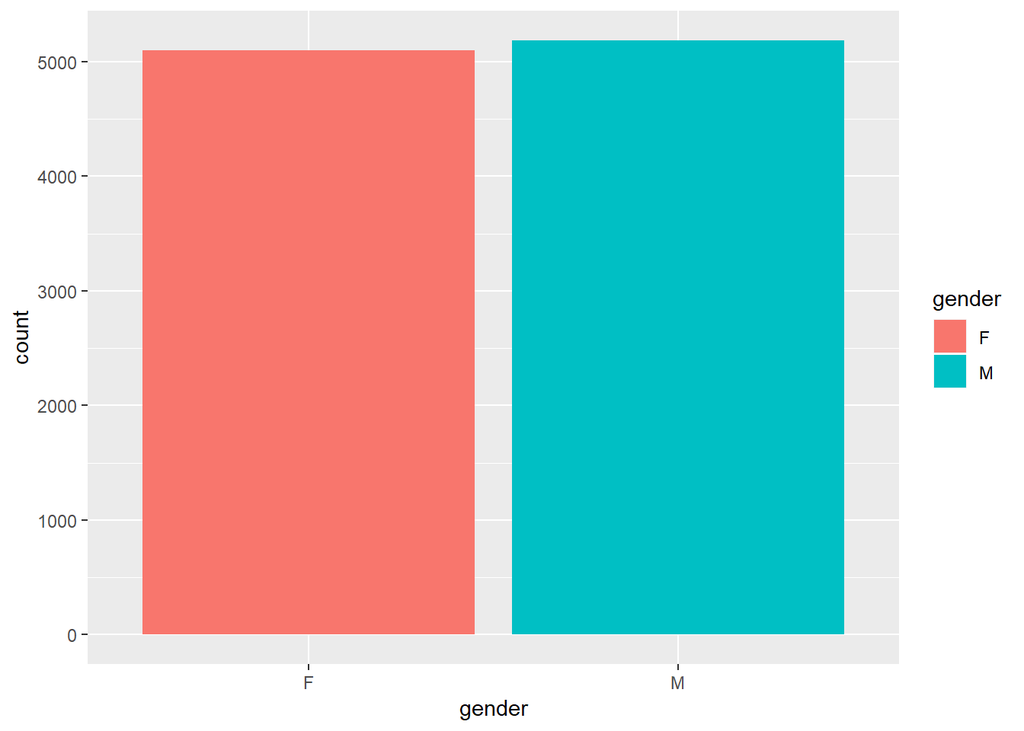

```r
ggplot(data=df)+geom_bar(mapping = aes(gender,fill=gender))
```

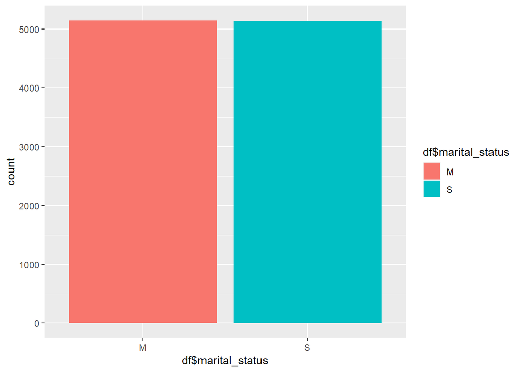

```r
ggplot(data=df)+geom_bar(mapping = aes(df$marital_status,fill=df$marital_status))
```

> 顾客职业分布描述

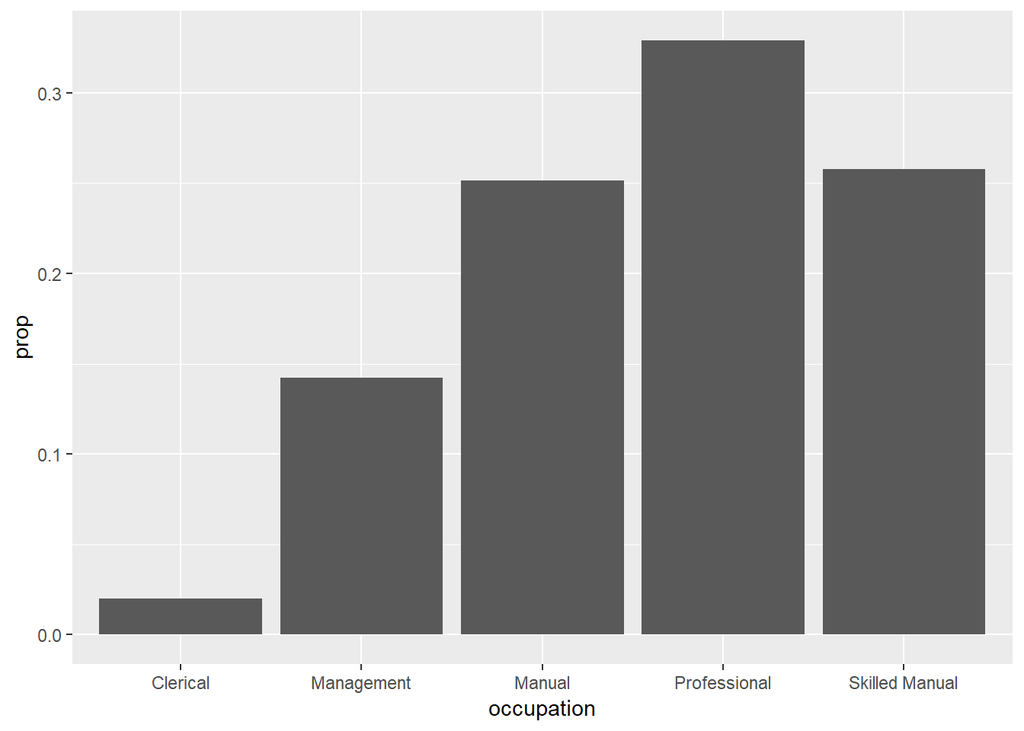

```r
#ggplot(data=df)+geom_bar(mapping = aes(occupation,fill=occupation))
ggplot(data = df) + geom_bar(mapping = aes(x = occupation, y = ..prop.., group = 1))
```

如图所示，职业为Professional的顾客数量最多，占顾客总人数的30%以上，其次是职业为Skilled Manual和Manual的顾客，各占顾客总人数的25%，职业为Management的顾客人数占15%，职业为Clerical的顾客人数最少，只占顾客总人数的2%。

> 顾客收入水平描述
1. 最低收入描述

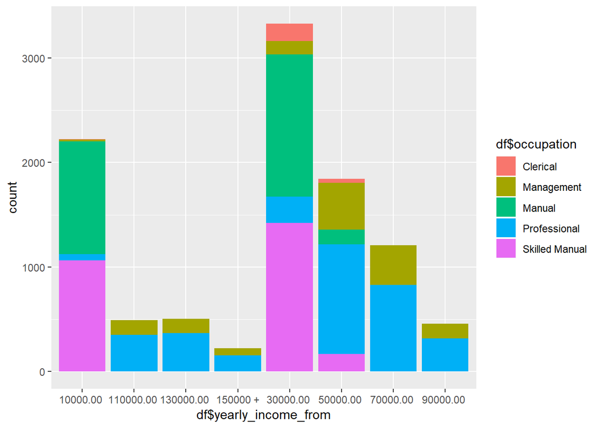

```r
ggplot(data=df)+geom_histogram(mapping = aes(df$yearly_income_from,fill=df$occupation),stat = "count")
```

2. 最高收入描述

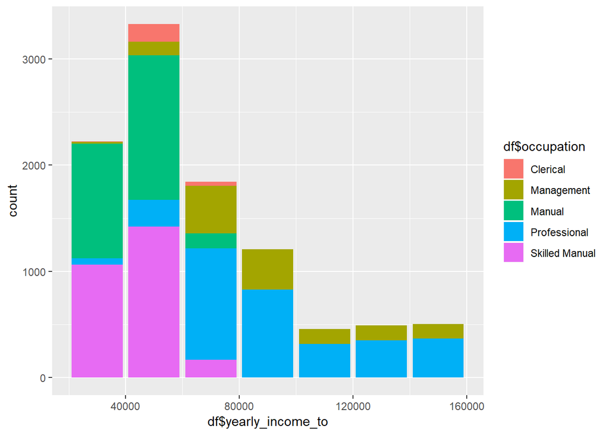

```r
ggplot(data=df)+geom_histogram(mapping = aes(df$yearly_income_to,fill=df$occupation),stat = "count")
```

由以上两图，顾客中工资高的人少于工资较低的人，说明FoodMart顾客群体总体而言偏向低收入人群。

> 顾客子女数量描述
1. 顾客当下家中孩子数量

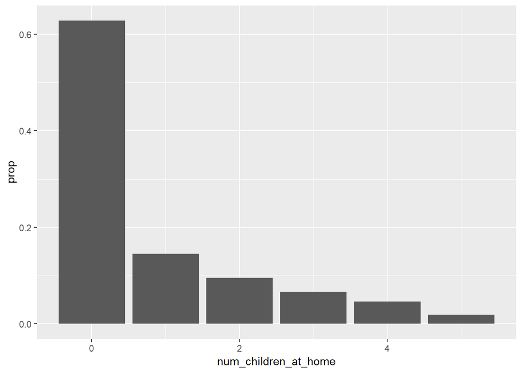

```r
ggplot(data=df)+geom_bar(mapping = aes(x=num_children_at_home, y = ..prop.., group = 1))
```

如图所示，60%以上的顾客现在家中没有孩子需要抚养，家中孩子数量为1-4的顾客人数越来越少。绝大多数客户当下家中没有或只有一个孩子需要抚养。

2. 顾客总共抚养的子女数量

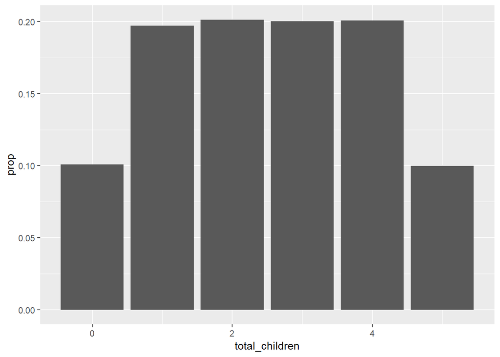

```r
ggplot(data=df)+geom_bar(mapping = aes(x=total_children, y = ..prop.., group = 1))
```

如图所示，90%以上的顾客养育过子女，抚养孩子数量为1-4的顾客人数几乎相同，各占总人数的20%，抚养有5个孩子的顾客人数最少，只占总人数的10%。 以上数据非常有趣，养育过孩子的人很多，占90%左右，但是当下家里还有孩子需要抚养的人却连40%都不到，这是否说明我们的顾客是以中老年的人为主呢？

> 顾客年龄描述

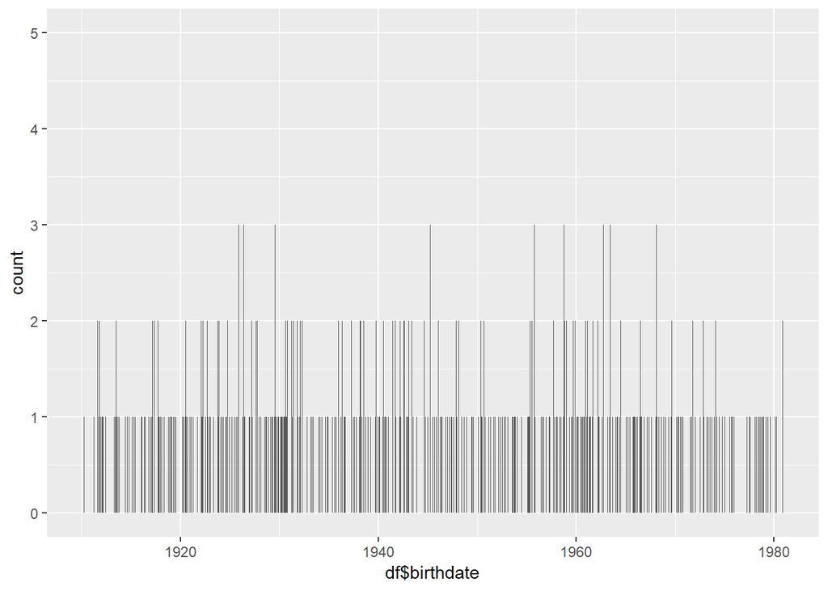

```r
ggplot(data=df)+geom_bar(mapping = aes(df$birthdate))
```

可见大部分顾客出生于1960年之前，甚至还有生于1920年之前的，以数据所在的1997年来看，顾客中大部分人已经年逾不惑，印证了我们上边的猜想。

### 全产品系列描述性统计

> 首先读取数据集，载入必要R包

```r
library(ggplot2)
dp=read.csv("E:/BDA/group_homework/sales_fact_1997.csv",sep=",",header = TRUE,encoding = "utf-8")
```

> 查看基本数据信息

```r
class(dp)
```

```
## [1] "data.frame"
```

```r
dim(dp)
```

```
## [1] 210429     11
```

```r
head(dp)
```

```
##   product_id time_id customer_id promotion_id store_id store_sales
## 1        337     371        6280            0        2        1.50
## 2       1512     371        6280            0        2        1.62
## 3        963     371        4018            0        2        2.40
## 4        181     371        4018            0        2        2.79
## 5       1383     371        4018            0        2        5.18
## 6       1306     371        4018            0        2        7.41
##   store_cost unit_sales    alpha_class product_class product_class_name
## 1       0.51          2           Food            58               Soup
## 2       0.63          3           Food             5              Pasta
## 3       0.72          1           Food            58               Soup
## 4       1.03          3           Food            61   Fresh Vegetables
## 5       2.18          2 Non-Consumable            56   Plastic Utensils
## 6       2.74          3          Drink            76               Milk
```

```r
tail(dp)
```

```
##        product_id time_id customer_id promotion_id store_id store_sales
## 210424        397     806        7607            0       17        4.05
## 210425       1466     806        7607            0       17        5.40
## 210426        230     806        7607            0       17        3.57
## 210427        407     806        7607            0       17        9.63
## 210428        291     806        7607            0       17       11.10
## 210429        640     806        7607            0       17       10.36
##        store_cost unit_sales alpha_class product_class product_class_name
## 210424       1.54          3        Food            63       French Fries
## 210425       2.00          3        Food            45            Cookies
## 210426       1.50          3        Food            54            Popcorn
## 210427       4.72          3        Food            10          TV Dinner
## 210428       4.55          5        Food            49        Cooking Oil
## 210429       4.25          4        Food            62  Canned Vegetables
```

```r
summary(dp)
```

```
##    product_id        time_id        customer_id     promotion_id
##  Min.   :   1.0   Min.   : 367.0   Min.   :    3   Min.   :   0.0
##  1st Qu.: 397.0   1st Qu.: 591.0   1st Qu.: 2143   1st Qu.:   0.0
##  Median : 786.0   Median : 779.0   Median : 4351   Median :   0.0
##  Mean   : 783.7   Mean   : 756.4   Mean   : 4380   Mean   : 250.2
##  3rd Qu.:1173.0   3rd Qu.: 927.0   3rd Qu.: 6319   3rd Qu.: 222.0
##  Max.   :1559.0   Max.   :1065.0   Max.   :10277   Max.   :1893.0
##
##     store_id      store_sales       store_cost       unit_sales
##  Min.   : 1.00   Min.   : 0.500   Min.   : 0.150   Min.   :1.000
##  1st Qu.: 7.00   1st Qu.: 3.800   1st Qu.: 1.490   1st Qu.:3.000
##  Median :13.00   Median : 5.940   Median : 2.380   Median :3.000
##  Mean   :12.84   Mean   : 6.534   Mean   : 2.615   Mean   :3.086
##  3rd Qu.:17.00   3rd Qu.: 8.670   3rd Qu.: 3.480   3rd Qu.:4.000
##  Max.   :24.00   Max.   :23.640   Max.   :10.290   Max.   :6.000
##
##          alpha_class     product_class           product_class_name
##  Drink         : 19367   Min.   :  1.00   Fresh Vegetables: 16293
##  Food          :151273   1st Qu.: 30.00   Fresh Fruit     :  9363
##  Non-Consumable: 39789   Median : 58.00   Soup            :  6185
##                          Mean   : 54.36   Cheese          :  6163
##                          3rd Qu.: 79.00   Dried Fruit     :  6018
##                          Max.   :110.00   Cookies         :  5381
##                                           (Other)         :161026
```

> 产品主要类别销量统计

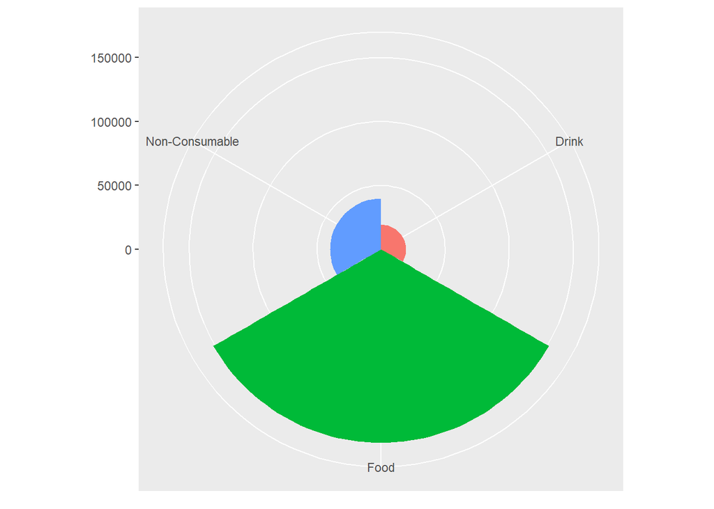

```r
bar <- ggplot(data = dp) +
  geom_bar(
    mapping = aes(x = alpha_class, fill = alpha_class),
    show.legend = FALSE,
    width = 1
  ) +
  theme(aspect.ratio = 1) +
  labs(x = NULL, y = NULL)
bar + coord_polar()
```

> 产品次要类别销量统计

```r
bar <- ggplot(data = dp) +
  geom_bar(
    mapping = aes(x = product_class_name, fill = product_class_name),
    show.legend = FALSE,
    width = 1
  ) +
  theme(aspect.ratio = 1) +
  labs(x = NULL, y = NULL)

summary(dp$product_class_name)
```

```
##   Fresh Vegetables        Fresh Fruit               Soup
##              16293               9363               6185
##             Cheese        Dried Fruit            Cookies
##               6163               6018               5381
##               Wine  Canned Vegetables        Paper Wipes
##               4059               3987               3973
##  Frozen Vegetables               Nuts    Chocolate Candy
##               3470               3424               3396
##               Milk              Chips          Preserves
##               3387               3262               3256
##               Eggs         Lightbulbs       Sliced Bread
##               3185               2811               2808
##            Muffins   Personal Hygiene               Dips
##               2761               2745               2739
##            Waffles              Pizza        Cooking Oil
##               2733               2692               2689
##             Cereal         Deli Meats          Batteries
##               2665               2664               2662
##          Popsicles              Juice             Coffee
##               2662               2649               2646
##               Soda              Pasta          Ice Cream
##               2630               2449               2122
##      Peanut Butter        Deli Salads            Shampoo
##               2091               2055               2054
##          TV Dinner     Frozen Chicken                Jam
##               2053               2044               2039
##           Hot Dogs             Spices            Bologna
##               2027               2013               2010
##    Flavored Drinks       French Fries   Plastic Utensils
##               2006               2006               1974
##            Popcorn             Donuts              Jelly
##               1974               1959               1953
##           Cleaners               Rice          Hamburger
##               1950               1584               1426
##      Cold Remedies          Mouthwash             Yogurt
##               1418               1404               1399
##       Canned Fruit         Hard Candy               Tuna
##               1392               1373               1370
##       Paper Dishes              Sugar       Nasal Sprays
##               1368               1366               1364
```

[output cut: 13 more lines]

```
##                687                686                685
## Computer Magazines      Fresh Chicken      Pots and Pans
##                684                684                680
##          Chocolate            Oysters                Gum
##                673                673                672
##       Screwdrivers        Conditioner           Pancakes
##                671                667                667
##             Bagels           Sardines         Sunglasses
##                663                663                663
##             Shrimp       Toothbrushes     Toilet Brushes
##                662                662                660
##         Fresh Fish            Candles             Sauces
##                651                650                643
##            (Other)
##               1881
```

## 顾客群体划分与价值评估——聚类（K-Means）

本分析团队基于个人收入与消费行为两个维度共4个关键变量，截取宽度为两年的历史数据，使用K-Means聚类方法对FoodMart顾客群体进行挖掘与分析，通过R语言在Rtudio上进行实现。

> 关键变量描述与数据预处理